# CENT: Bioinformatics Research Scientist

### 1.8.2 RINscore

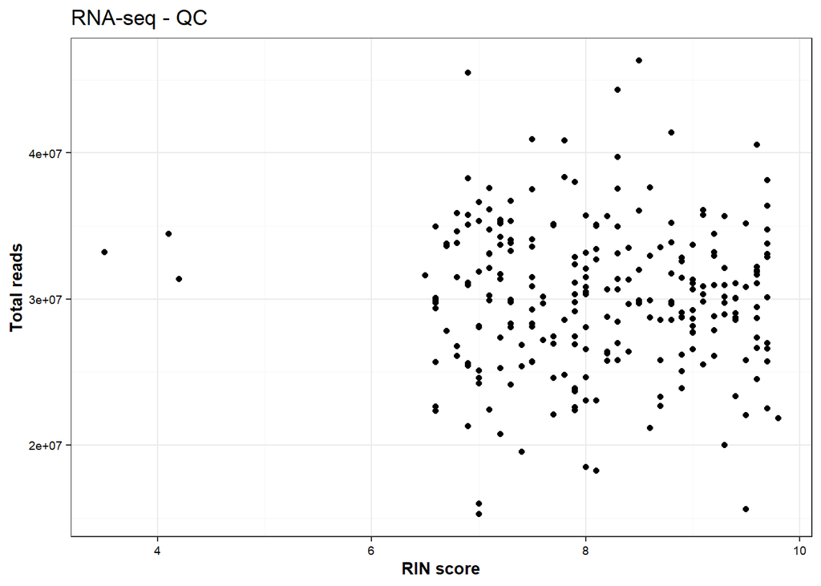

```r
p <- ggplot(rnameta, aes(rin_score, total_reads)) +
  geom_point()+
  labs(
    title = "RNA-seq - QC",
    x = "RIN score",
    y = "Total reads"
  ) +
  theme_bw() +
  theme(
    panel.grid.minor = element_line(color = "gray97"),
    axis.title.y = element_text(size = 10, color = "black", face = "bold"),
    axis.title.x = element_text(size = 10, color = "black", face = "bold"),
    axis.text.y = element_text(size = 7, color = "black"),
    axis.text.x = element_text(size = 7, color = "black"),
    strip.text = element_text(size = 9, face = "bold"),
    legend.position = "bottom")

p
```

```r
ggsave("part1/rnaseq_rinscore.png", p, height=4,width=6.8, dpi=300)
```

**Interpretation:** The scatter plot of total reads versus RIN score shows no strong correlation between RNA integrity and sequencing depth. RIN scores range from approximately 3 to 10, while total reads remain broadly consistent regardless of RIN value. This indicates that lower-quality RNA samples were not systematically under-sequenced, and that RIN-related variation is unlikely to confound expression-level analyses after appropriate normalization.

### 1.8.3 Gene-level QC

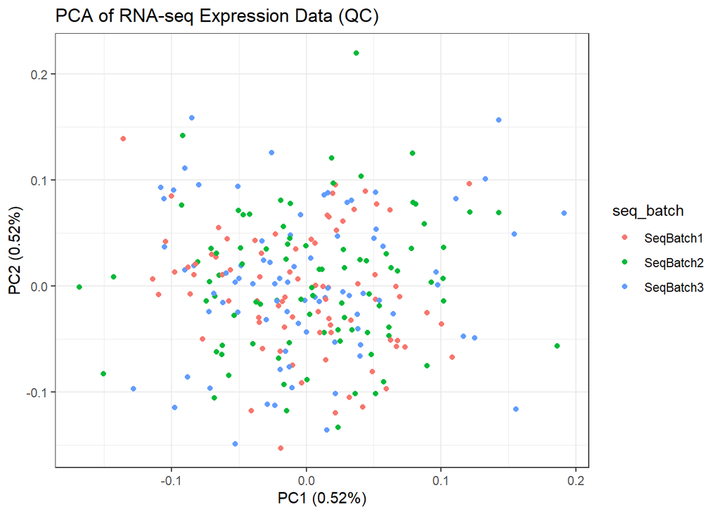

```r
dge <- DGEList(counts = rnacounts)
keep <- filterByExpr(dge)
dge <- dge[keep, , keep.lib.sizes=FALSE]
dge <- calcNormFactors(dge)

logcpm <- cpm(dge, log=TRUE, prior.count=1)
pca_rna <- prcomp(t(logcpm))

p <- autoplot(pca_rna,
         data = rnameta,
         colour = "seq_batch") +
  theme_bw() +
  labs(title = "PCA of RNA-seq Expression Data (QC)")

p
```

```r
ggsave("part1/rnaseq_pca.png", p, height=4, width=6.8, dpi=300)
```

**Interpretation:** The PCA of normalized RNA-seq expression data demonstrates strong overlap among the three sequencing batches (SeqBatch1, SeqBatch2, SeqBatch3), with no clear batch-driven separation along PC1 or PC2 (each explaining 0.52% of variance). This confirms that batch effects do not dominate the primary variance structure of the expression data, supporting the decision to retain sequencing batch as a covariate in downstream models rather than applying aggressive batch correction at the exploratory stage.

## 1.9 Sample Filtering

To ensure that all analyses were based on valid and comparable observations, I applied a minimal, QC‑driven filtering strategy. Rather than imposing arbitrary numerical thresholds, samples were removed only when they lacked essential identifiers (sample ID, patient ID) or key variables required for modeling, such as age or NCS. For metabolomics and radiomics, rows with no usable numeric data were excluded, and RNA‑seq samples with extremely low library size were removed, although none fell below this threshold. This approach preserves as much information as possible in a rare‑disease cohort while ensuring that downstream models are fit on structurally complete and interpretable data.

```r
# Remove samples missing essential clinical variables
clinical <- clinical %>%
  filter(
    !is.na(sample_id),
    !is.na(patient_id),
    !is.na(age),
    !is.na(ncs)
  )

# Remove metabolomics samples with all missing numeric values
metabol <- metabol %>%
  filter(rowSums(is.na(across(where(is.numeric)))) <
         ncol(across(where(is.numeric))))

# Remove radiomics samples with all missing numeric values
radiomics <- radiomics %>%
  filter(rowSums(is.na(across(where(is.numeric)))) <
         ncol(across(where(is.numeric))))

# RNA-seq: remove samples with extremely low library size (none in my data)
libsize <- colSums(rnacounts)
rnacounts <- rnacounts[, libsize > 1e6]
rnameta <- rnameta %>% filter(sample_id %in% colnames(rnacounts))

# Save filtering files
if (!dir.exists("data_clean"))
  dir.create("data_clean")

write.csv(clinical, "data_clean/clinical_filtered.csv", row.names = FALSE)
write.csv(metabol,  "data_clean/metabol_filtered.csv",  row.names = FALSE)
write.csv(radiomics, "data_clean/radiomics_filtered.csv", row.names = FALSE)
write_tsv(
  tibble::rownames_to_column(as.data.frame(rnacounts), var = "gene_id"),
  "data_clean/rnacounts_filtered.tsv"
)
write_csv(rnameta, "data_clean/rnameta_filtered.csv")
```

## 1.10 Save Environment

```r
save.image(file = "part1/workspace_part1.rda")

rm(list=ls())
```

# 2 **PART 2 - Multi-omics Integration**

## 2.1 Setup

```r
library(tibble)
library(lmerTest)
library(lme4)
library(purrr)
library(vctrs)
library(furrr)
library(broom)
library(broom.mixed)
library(mediation)
```

## 2.2 Load Data

```r
clinical   <- read.csv("data_clean/clinical_filtered.csv")
radiomics  <- read.csv("data_clean/radiomics_filtered.csv")
metabol    <- read.csv("data_clean/metabol_filtered.csv")
rnameta    <- read.csv("data_clean/rnameta_filtered.csv")
rnacounts_raw <- fread("data_clean/rnacounts_filtered.tsv", data.table = FALSE)
colnames(rnacounts_raw)[1] <- "genes"
rnacounts_raw <- rnacounts_raw %>%
  filter(!is.na(genes), genes != "")
rnacounts_raw$genes <- make.unique(rnacounts_raw$genes)
rownames(rnacounts_raw) <- rnacounts_raw$genes
rnacounts <- rnacounts_raw[, -1, drop = FALSE]
rnacounts[] <- lapply(rnacounts, as.numeric)
rnacounts <- as.matrix(rnacounts)
mode(rnacounts) <- "numeric"
rm(rnacounts_raw)

# Create directory "part2"
if (!dir.exists("part2"))
  dir.create("part2")
```

## 2.3 Analytical Strategy

Given the small cohort and uneven data coverage, I focused on a clinically guided, longitudinal integration strategy. Instead of maximizing predictive power, the aim was to find molecular and imaging signals that track with neurocognitive trajectories and account for repeated measures and disease differences.

### 2.3.1 a) Longitudinal Modeling of Neurocognitive Trajectory

Neurocognitive function was modeled using NCS as a repeated‑measures outcome. Because patients are assessed at different ages and begin with different baseline cognitive levels, I used a linear mixed‑effects model that includes a patient‑specific random intercept and treats age as a continuous time variable. The fixed effects capture major clinical sources of variation, including UCD subtype, clinical severity, transplant status, cumulative HAE event burden, and gender. This structure reflects the clinical reality that NCS changes with both normal development and cumulative metabolic injury.

```r
clinical <- clinical %>%
  group_by(patient_id) %>%
  mutate(cum_HAE = cumsum(n_hae))

model_ncs <- lmer(
  ncs ~ age + severity + subtype + sex + transplant + cum_HAE +
    (1 | patient_id),
  data = clinical
)

summary(model_ncs)
```

```
## Linear mixed model fit by REML. t-tests use Satterthwaite's method [
## lmerModLmerTest]
## Formula: ncs ~ age + severity + subtype + sex + transplant + cum_HAE +
##     (1 | patient_id)
##    Data: clinical
##
## REML criterion at convergence: 1611.1
##
## Scaled residuals:
##      Min       1Q   Median       3Q      Max
## -2.44057 -0.58073 -0.02283  0.58594  2.30661
##
## Random effects:
##  Groups     Name        Variance Std.Dev.
##  patient_id (Intercept) 108.88   10.434
##  Residual                22.25    4.717
## Number of obs: 248, groups:  patient_id, 60
##
## Fixed effects:
##                 Estimate Std. Error        df t value Pr(>|t|)
## (Intercept)     91.09420    6.21819  38.78591  14.650  < 2e-16 ***
## age             -0.72103    0.30808  57.48839  -2.340  0.02275 *
## severitysevere  -9.34891    3.25576  38.42001  -2.872  0.00661 **
## subtypeASL       4.59321    6.12790  34.75369   0.750  0.45857
## subtypeASS1      3.81223    5.25998  34.41753   0.725  0.47350
## subtypeCPS1      0.02804    7.96019  34.81867   0.004  0.99721
## subtypeOTC       7.08731    4.89364  34.67982   1.448  0.15652
## sexM            -2.09109    3.04853  34.32435  -0.686  0.49736
## transplant       5.39320    3.50630  33.60621   1.538  0.13338
## cum_HAE         -1.40502    0.18327 234.73375  -7.666 4.66e-13 ***
## ---
## Signif. codes:  0 '***' 0.001 '**' 0.01 '*' 0.05 '.' 0.1 ' ' 1
##
## Correlation of Fixed Effects:
##             (Intr) age    svrtys sbtASL sbASS1 sbCPS1 sbtOTC sexM   trnspl
## age         -0.515
## severitysvr -0.361  0.276
## subtypeASL  -0.451 -0.147 -0.133
## subtypeASS1 -0.687  0.005  0.078  0.614
## subtypeCPS1 -0.291 -0.031 -0.264  0.416  0.428
## subtypeOTC  -0.663 -0.038 -0.022  0.670  0.775  0.492
## sexM        -0.505  0.121  0.224  0.078  0.193 -0.116  0.121
## transplant  -0.103 -0.056 -0.036 -0.044  0.003  0.075 -0.016  0.087
## cum_HAE      0.191 -0.461 -0.277  0.074  0.001 -0.022  0.010 -0.039  0.044
```

### 2.3.2 b) Transcriptomic Signals Associated with Neurocognitive Decline

RNA‑seq counts were filtered for low expression, normalized using TMM, and log‑transformed. For each gene, I fit a gene‑wise mixed‑effects model in which expression was modeled as a function of NCS, age, and sequencing batch, with a patient‑specific random intercept to account for repeated measures. This approach differs from classical differential expression because, instead of comparing predefined groups, it identifies genes whose expression tracks with neurocognitive function over time.

```r
# RNAseq Preprocessing + Gene-wise Mixed Models
counts <- rnacounts
meta <- rnameta

dge <- DGEList(counts = counts)
keep <- filterByExpr(dge)
dge <- dge[keep, , keep.lib.sizes = FALSE]
dge <- calcNormFactors(dge)
logcpm <- cpm(dge, log = TRUE, prior.count = 1)

results <- list()

for (g in rownames(logcpm)) {
  df <- data.frame(
    expr = logcpm[g, ],
    sample_id = colnames(logcpm)
  ) %>%
    left_join(meta, by = "sample_id") %>%
    left_join(clinical, by = "sample_id")

fit <- lmerTest::lmer(
    expr ~ ncs + age + seq_batch + (1 | patient_id),
    data = df,
    REML = FALSE
  )

  results[[g]] <- broom.mixed::tidy(
    fit,
    effects = "fixed"
  )
}

gene_results <- bind_rows(results, .id = "gene") %>%
  filter(term == "ncs") %>%
  mutate(FDR = p.adjust(p.value, method = "BH"))

save(gene_results, file="part2/results_b.rda")
```

### 2.3.3 c) Multimodal Integration Across Metabolomics, Radiomics, and Transcriptomics

Because sample overlap across modalities is limited, I used a late‑integration strategy. Metabolomics and radiomics were each reduced to latent components using PCA, and transcriptomic variation was summarized through gene‑level mixed‑effects associations with NCS. The leading PCs from each modality were then added to the longitudinal NCS model as time‑varying covariates.

```r
# PCA for Metabolomics + Radiomics
metab <- metabol %>%
  dplyr::select(sample_id, where(is.numeric))

# Metabolomics
metab_mat <- metab %>%
  tibble::column_to_rownames("sample_id") %>%
  as.matrix()

metab_imp <- apply(
  metab_mat,
  2,
  function(x) {
    x[is.na(x)] <- median(x, na.rm = TRUE)
    x
  }
)

pca_metab <- prcomp(scale(metab_imp))

# Turn PCA outputs into keyed data frames
metab_PC <- data.frame(
  sample_id = rownames(pca_metab$x),
  metab_PC1 = pca_metab$x[, 1]
)

# Radiomics
radio <- radiomics %>%
  dplyr::select(sample_id, where(is.numeric))

radio_mat <- radio %>%
  tibble::column_to_rownames("sample_id") %>%
  as.matrix()

radio_imp <- apply(
  radio_mat,
  2,
  function(x) {
    x[is.na(x)] <- median(x, na.rm = TRUE)
    x
  }
)

pca_radio <- prcomp(scale(radio_imp))

# Turn PCA outputs into keyed data frames
radio_PC <- data.frame(
  sample_id = rownames(pca_radio$x),
  radio_PC1 = pca_radio$x[, 1]
)

clinical <- clinical %>%
  left_join(metab_PC, by = "sample_id") %>%
  left_join(radio_PC, by = "sample_id")

model_integrated <- lmer(
  ncs ~ age + severity + subtype + sex + transplant + cum_HAE +
    metab_PC1 + radio_PC1 +
    (1 | patient_id),
  data = clinical
)

summary(model_integrated)
```

```
## Linear mixed model fit by REML. t-tests use Satterthwaite's method [
## lmerModLmerTest]
## Formula: ncs ~ age + severity + subtype + sex + transplant + cum_HAE +
##     metab_PC1 + radio_PC1 + (1 | patient_id)
##    Data: clinical
##
## REML criterion at convergence: 1571.2
##
## Scaled residuals:
##      Min       1Q   Median       3Q      Max
## -2.37462 -0.59950  0.03215  0.56698  2.24912
##
## Random effects:
##  Groups     Name        Variance Std.Dev.
##  patient_id (Intercept) 95.64    9.779
##  Residual               20.72    4.552
## Number of obs: 245, groups:  patient_id, 60
##
## Fixed effects:
##                Estimate Std. Error       df t value Pr(>|t|)
## (Intercept)     88.1664     5.8752  42.7361  15.006  < 2e-16 ***
## age             -0.3706     0.3037  62.0497  -1.220 0.226915
## severitysevere -12.6914     3.2542  57.3473  -3.900 0.000255 ***
## subtypeASL       3.5696     5.7595  38.8230   0.620 0.539023
## subtypeASS1      6.0558     4.9851  39.9191   1.215 0.231585
## subtypeCPS1      0.1157     7.4904  39.2266   0.015 0.987759
## subtypeOTC       4.8012     4.6368  40.1596   1.035 0.306657
## sexM            -1.2045     2.8680  38.5229  -0.420 0.676838
## transplant       5.7974     3.2958  37.7106   1.759 0.086684 .
## cum_HAE         -1.2970     0.1778 227.8491  -7.295  4.9e-12 ***
## metab_PC1       -1.3464     0.4135 178.0356  -3.256 0.001353 **
## radio_PC1       -0.7687     0.2872 178.1092  -2.677 0.008128 **
## ---
## Signif. codes:  0 '***' 0.001 '**' 0.01 '*' 0.05 '.' 0.1 ' ' 1
##
## Correlation of Fixed Effects:
##             (Intr) age    svrtys sbtASL sbASS1 sbCPS1 sbtOTC sexM   trnspl
## age         -0.521
## severitysvr -0.309  0.158
## subtypeASL  -0.443 -0.154 -0.111
## subtypeASS1 -0.679  0.010  0.067  0.607
## subtypeCPS1 -0.285 -0.040 -0.234  0.417  0.430
## subtypeOTC  -0.648 -0.047 -0.012  0.665  0.743  0.481
## sexM        -0.505  0.124  0.199  0.076  0.197 -0.114  0.113
## transplant  -0.104 -0.053 -0.038 -0.044  0.005  0.074 -0.016  0.089
## cum_HAE      0.177 -0.416 -0.280  0.071  0.019 -0.018 -0.008 -0.029  0.047
## metab_PC1    0.024 -0.045  0.048  0.007 -0.137 -0.046  0.132 -0.047 -0.008
## radio_PC1    0.084 -0.267  0.334  0.042  0.003  0.046  0.006 -0.024 -0.011
##             cm_HAE mt_PC1
## age
## severitysvr
## subtypeASL
## subtypeASS1
## subtypeCPS1
## subtypeOTC
## sexM
## transplant
## cum_HAE
## metab_PC1   -0.129
## radio_PC1   -0.035 -0.008
```

**Interpretation:** In this framework, metabolomic components—largely reflecting amino‑acid and energy‑metabolism pathways—showed the strongest alignment with neurocognitive decline. Radiomics components captured structural and microstructural variation but were less tightly linked to NCS. Overall, this suggests that systemic metabolic dysregulation is more closely tied to neurocognitive outcomes than imaging variation in this cohort.

### 2.3.4 d) Mediation Analysis: Ammonia, Glx/Cr, and Neurocognition

To test the hypothesis that brain Glx/Cr mediates ammonia‑related neurotoxicity, I performed a mediation analysis using plasma ammonia as the exposure, the Glx/Cr spectroscopy ratio as the mediator, and NCS as the outcome, with patient‑specific random intercepts to account for repeated measures.

```r
df_patient <- clinical %>%
  left_join(radiomics %>% dplyr::select(sample_id, Glx_Cr_ratio), by = "sample_id") %>%
  group_by(patient_id) %>%
  summarise(
    ammonia = mean(ammonia, na.rm = TRUE),
    Glx_Cr_ratio = mean(Glx_Cr_ratio, na.rm = TRUE),
    ncs = mean(ncs, na.rm = TRUE),
    age = dplyr::first(age),
    .groups = "drop"
  ) %>%
  filter(!is.na(ammonia), !is.na(Glx_Cr_ratio), !is.na(ncs), !is.na(age))

med_mod <- lm(Glx_Cr_ratio ~ ammonia + age, data = df_patient)
out_mod <- lm(ncs ~ ammonia + Glx_Cr_ratio + age, data = df_patient)

mediation_res <- mediation::mediate(
  med_mod, out_mod,
  treat = "ammonia",
  mediator = "Glx_Cr_ratio",
  boot = TRUE,
  sims = 1000
)
```

```
## Running nonparametric bootstrap
```

```r
summary(mediation_res)
```

```
##
## Causal Mediation Analysis
##
## Nonparametric Bootstrap Confidence Intervals with the Percentile Method
##
##                 Estimate 95% CI Lower 95% CI Upper p-value
## ACME           -0.067046    -0.147023     0.048443   0.202
## ADE            -0.104928    -0.266985    -0.008972   0.030 *
## Total Effect   -0.171974    -0.296520    -0.094261  <2e-16 ***
## Prop. Mediated  0.389861    -0.273802     0.916212   0.202
## ---
## Signif. codes:  0 '***' 0.001 '**' 0.01 '*' 0.05 '.' 0.1 ' ' 1
##
## Sample Size Used: 60
##
##
## Simulations: 1000
```

This analysis has several **strengths**. It uses longitudinal models that properly account for repeated measures, integrates information across transcriptomics, metabolomics, and radiomics, and incorporates mechanistic hypothesis testing grounded in established UCD biology. The covariate structure is clinically informed, reflecting known sources of heterogeneity in neurocognitive outcomes. At the same time, there are important **limitations**. The rare‑disease sample size reduces statistical power, multimodal overlap is incomplete, and missingness is unlikely to be fully at random. In addition, the mediation analysis is constrained by uncertainty in the timing of measurements, which limits causal interpretation. Together, these factors frame the results as exploratory but biologically coherent within the context of UCD.

## 2.4 Save Environment

```r
save.image(file = "part2/workspace_part2.rda")

rm(list=ls())
```

# 3 **PART 3 - Code Review**

## 3.1 Setup

```r
library(ggrepel)
```

## 3.2 Severity Classification

### 3.2.1 Minor Issues

#### 3.2.1.1 Inconsistent naming of variables

**What is wrong:** Different naming conventions (pvalue, padj, FDR). **Downstream consequences:** Confusion and potential coding errors. **How to fix:** Standardize naming (e.g., PValue, FDR).

#### 3.2.1.2 Plot labeling inconsistencies

**What is wrong:** Mismatch between axis labels and transformations. **Downstream consequences:** Misleading visualization. **How to fix:** Ensure labels match transformations.

#### 3.2.1.3 Lack of reproducibility checks

**What is wrong:** No seed setting or logging for some steps. **Downstream consequences:** Difficulty reproducing results. **How to fix:** Set seeds and document steps.

### 3.2.2 Moderate Issues

#### 3.2.2.1 Encoding categorical variables as numeric

**What is wrong:** Severity and subtype converted to numeric codes. **Downstream consequences:** Incorrect modeling assumptions and misleading coefficients. **How to fix:** Use factor() for categorical variables.

#### 3.2.2.2 Volcano plot uses inconsistent transformations

**What is wrong:** Manual log transformation of fold change instead of using logFC. **Downstream consequences:** Incorrect interpretation of effect size. **How to fix:** Use logFC directly from edgeR output.

#### 3.2.2.3 Permutation test built on incorrect DE method

**What is wrong:** Permutation test relies on t-test results. **Downstream consequences:** Invalid null distribution. **How to fix:** Use edgeR inside permutation loop.

#### 3.2.2.4 No check for missing or mismatched samples

**What is wrong:** Merging datasets without verifying sample loss. **Downstream consequences:** Reduced sample size and potential bias. **How to fix:** Explicitly report and check sample counts before and after merge.

### 3.2.3 Critical Issues

#### 3.2.3.1 Using t-test / lm() for RNA-seq counts

**What is wrong:** RNA-seq data are count-based and not normally distributed, so t-tests and linear models on raw counts are inappropriate. **Downstream consequences:** Invalid statistical inference, inflated false positives or negatives. **How to fix:** Use edgeR or DESeq2 with a negative binomial model.

#### 3.2.3.2 Not aligning count matrix with metadata

**What is wrong:** Sample order between counts and metadata may not match. **Downstream consequences:** Incorrect sample-to-group assignment leading to completely wrong results. **How to fix:** Reorder counts using metadata sample IDs and verify with stopifnot().

#### 3.2.3.3 Improper handling of duplicated gene names

**What is wrong:** Duplicated genes were not resolved before setting row names. **Downstream consequences:** Errors or incorrect aggregation of gene counts. **How to fix:** Use make.unique() or aggregate duplicates properly.

#### 3.2.3.4 Filtering genes using mean expression

**What is wrong:** Filtering based on rowMeans > 10 is not appropriate for RNA-seq. **Downstream consequences:** Bias in retained genes and reduced statistical power. **How to fix:** Use edgeR::filterByExpr().

#### 3.2.3.5 Using raw p-values instead of adjusted p-values

**What is wrong:** Significance defined using pvalue < 0.05. **Downstream consequences:** Inflated false discovery rate. **How to fix:** Use FDR (Benjamini-Hochberg correction).

## 3.3 Rewritten Code

### 3.3.1 File Paths

```r
counts_path   <- "data/rnaseq_counts.tsv"
clinical_path <- "data/clinical.csv"
metab_path    <- "data/metabolomics.csv"

# Create directory "part3"
if (!dir.exists("part3"))
  dir.create("part3")
```

### 3.3.2 Load Data

```r
counts_df <- fread(counts_path,data.table = FALSE)
clinical  <- read.csv(clinical_path, stringsAsFactors = FALSE)
metab     <- read.csv(metab_path, stringsAsFactors = FALSE)

if (ncol(counts_df) < 2) {
  stop("Counts file must contain a gene column plus at least one sample column.")
}

colnames(counts_df)[1] <- "genes"
counts_df <- counts_df[!is.na(counts_df$genes) & counts_df$genes != "", , drop = FALSE]
counts_df$genes <- make.unique(as.character(counts_df$genes))

counts_mat <- as.matrix(counts_df[, -1, drop = FALSE])
storage.mode(counts_mat) <- "numeric"
rownames(counts_mat) <- counts_df$genes

if (anyNA(counts_mat)) {
  stop("Count matrix contains missing or non-numeric values after import.")
}

# RNA-seq counts should be non-negative integers
if (any(counts_mat < 0)) {
  stop("Count matrix contains negative values, which are invalid for RNA-seq counts.")
}
```

### 3.3.3 Align Clinical Metadata to Count Matrix

```r
if (!"sample_id" %in% names(clinical)) {
  stop("clinical.csv must contain a 'sample_id' column.")
}

expr_samples <- colnames(counts_mat)
common_samples <- intersect(expr_samples, clinical$sample_id)

if (length(common_samples) == 0) {
  stop("No overlapping sample IDs between counts matrix and clinical metadata.")
}

lost_from_counts  <- setdiff(expr_samples, clinical$sample_id)
lost_from_clinical <- setdiff(clinical$sample_id, expr_samples)

if (length(lost_from_counts) > 0) {
  warning(
    "Samples present in expression data but missing in clinical metadata: ",
    paste(lost_from_counts, collapse = ", ")
  )
}

if (length(lost_from_clinical) > 0) {
  warning(
    "Samples present in clinical metadata but missing in expression data: ",
    paste(lost_from_clinical, collapse = ", ")
  )
}

metadata <- clinical %>%
  filter(sample_id %in% common_samples) %>%
  distinct(sample_id, .keep_all = TRUE)

if (nrow(metadata) != length(unique(metadata$sample_id))) {
  stop("Clinical metadata contains duplicated sample_id values.")
}

metadata <- metadata[match(common_samples, metadata$sample_id), , drop = FALSE]
counts_mat <- counts_mat[, metadata$sample_id, drop = FALSE]

stopifnot(identical(colnames(counts_mat), metadata$sample_id))

cat("Samples in expression data:", length(expr_samples), "\n")
```

```
## Samples in expression data: 248
```

```r
cat("Samples used after alignment:", ncol(counts_mat), "\n")
```

```
## Samples used after alignment: 248
```

### 3.3.4 Prepare Variables

```r
if (!"severity" %in% names(metadata)) {
  stop("clinical.csv must contain a 'severity' column.")
}

metadata <- metadata %>%
  filter(severity %in% c("mild", "severe"))

counts_mat <- counts_mat[, metadata$sample_id, drop = FALSE]
metadata$severity <- factor(metadata$severity, levels = c("mild", "severe"))

if (nlevels(droplevels(metadata$severity)) < 2) {
  stop("Need both mild and severe samples for differential expression analysis.")
}
```

### 3.3.5 Primary DE Analysis with EdgeR

```r
dge <- DGEList(counts = counts_mat)
keep <- filterByExpr(dge, group = metadata$severity)
dge <- dge[keep, , keep.lib.sizes = FALSE]

cat("Genes before filtering:", nrow(counts_mat), "\n")
```

```
## Genes before filtering: 17998
```

```r
cat("Genes after filtering:", nrow(dge), "\n")
```

```
## Genes after filtering: 17240
```

```r
# TMM normalization
dge <- calcNormFactors(dge)
design <- model.matrix(~ severity, data = metadata)
dge <- estimateDisp(dge, design)
fit <- glmQLFit(dge, design)
qlf <- glmQLFTest(fit, coef = "severitysevere")

de_results <- topTags(qlf, n = Inf)$table
de_results$gene <- rownames(de_results)
de_results$significant <- de_results$FDR < 0.05

cat("Significant genes (FDR < 0.05):", sum(de_results$significant, na.rm = TRUE), "\n") #7
```

```
## Significant genes (FDR < 0.05): 7
```

```r
write.csv(de_results, "part3/de_results_severe_vs_mild.csv", row.names = FALSE)
```

### 3.3.6 Adjusted Analysis for Covariates

```r
possible_covariates <- c("subtype", "age")
available_covariates <- possible_covariates[possible_covariates %in% names(metadata)]

metadata_adj <- metadata
if ("subtype" %in% available_covariates) {
  metadata_adj$subtype <- factor(metadata_adj$subtype)
}
if ("age" %in% available_covariates) {
  metadata_adj$age <- suppressWarnings(as.numeric(metadata_adj$age))
}

# Drop rows with missing covariates for adjusted analysis only.
if (length(available_covariates) > 0) {
  keep_samples_adj <- complete.cases(metadata_adj[, c("sample_id", "severity", available_covariates), drop = FALSE])
  metadata_adj <- metadata_adj[keep_samples_adj, , drop = FALSE]
  counts_adj <- counts_mat[, metadata_adj$sample_id, drop = FALSE]

  if (nrow(metadata_adj) >= 4 && nlevels(droplevels(metadata_adj$severity)) == 2) {
    dge_adj <- DGEList(counts = counts_adj)
    keep_adj <- filterByExpr(dge_adj, group = metadata_adj$severity)
    dge_adj <- dge_adj[keep_adj, , keep.lib.sizes = FALSE]
    dge_adj <- calcNormFactors(dge_adj)

    rhs <- paste(c("severity", available_covariates), collapse = " + ")
    design_adj <- model.matrix(as.formula(paste("~", rhs)), data = metadata_adj)

    if ("severitysevere" %in% colnames(design_adj)) {
      dge_adj <- estimateDisp(dge_adj, design_adj)
      fit_adj <- glmQLFit(dge_adj, design_adj)
      qlf_adj <- glmQLFTest(fit_adj, coef = "severitysevere")
      adjusted_results <- topTags(qlf_adj, n = Inf)$table
      adjusted_results$gene <- rownames(adjusted_results)
      adjusted_results$significant <- adjusted_results$FDR < 0.05

      write.csv(adjusted_results, "part3/de_results_adjusted.csv", row.names = FALSE)
      cat("Adjusted significant genes (FDR < 0.05):", sum(adjusted_results$significant, na.rm = TRUE), "\n")
    } else {
      warning("Adjusted design matrix did not contain severity coefficient; skipping adjusted analysis.")
    }
  } else {
    warning("Not enough complete samples to run adjusted analysis; skipping adjusted analysis.")
  }
} else {
  message("No subtype/age covariates available; adjusted analysis skipped.")
}
```

```
## Adjusted significant genes (FDR < 0.05): 7
```

### 3.3.7 Permutation Test

Permutation testing was performed using 100 permutations to obtain an initial, computationally efficient estimate of significance for exploratory analyses. While this number is sufficient to detect large effect sizes and to identify gross departures from the null hypothesis, higher numbers of permutations (e.g., ≥1,000 or ≥10,000) are generally preferred for more accurate p‑value estimation, particularly when p‑values are small or when results are intended for formal inference. Increasing the number of permutations improves the resolution and stability of the permutation‑based p‑value and reduces Monte Carlo error, at the cost of increased computational time. For confirmatory analyses or downstream hypothesis testing, a higher permutation count would therefore represent a more robust approach.

```r
run_edger_once <- function(count_matrix, group_factor) {
  group_factor <- factor(group_factor)

  if (nlevels(group_factor) != 2 || any(table(group_factor) < 2)) {
    return(NA_integer_)
  }

  d <- DGEList(counts = count_matrix)
  keep <- filterByExpr(d, group = group_factor)
  d <- d[keep, , keep.lib.sizes = FALSE]

  if (nrow(d) == 0) {
    return(0L)
  }

  d <- calcNormFactors(d)
  design <- model.matrix(~ group_factor)
  d <- estimateDisp(d, design)
  fit <- glmQLFit(d, design)
  test <- glmQLFTest(fit, coef = 2)

  sum(topTags(test, n = Inf)$table$FDR < 0.05, na.rm = TRUE)
}

run_permutation_test <- function(count_matrix, group_factor, n_perm = 100, seed = 42) {
  set.seed(seed)

  observed <- run_edger_once(count_matrix, group_factor)
  null <- numeric(n_perm)

  for (i in seq_len(n_perm)) {
    permuted_group <- sample(group_factor, replace = FALSE)
    null[i] <- run_edger_once(count_matrix, permuted_group)
  }

  list(
    observed = observed,
    null = null,
    p = mean(null >= observed, na.rm = TRUE)
  )
}

perm_full <- run_permutation_test(counts_mat, metadata$severity, n_perm = 100)
cat("Permutation p-value (full cohort):", perm_full$p, "\n")
```

```
## Permutation p-value (full cohort): 0
```

```r
# Non-transplant subset, only if transplant is available and has both groups
if ("transplant" %in% names(metadata)) {
  non_tx_idx <- which(metadata$transplant == 0)

  if (length(non_tx_idx) >= 4) {
    counts_notx <- counts_mat[, non_tx_idx, drop = FALSE]
    group_notx <- droplevels(metadata$severity[non_tx_idx])

    if (nlevels(group_notx) == 2 && all(table(group_notx) >= 2)) {
      perm_notx <- run_permutation_test(counts_notx, group_notx, n_perm = 100)
      cat("Permutation p-value (non-transplant subset):", perm_notx$p, "\n")
    } else {
      warning("Non-transplant subset does not contain enough mild and severe samples; skipping subset permutation test.")
    }
  } else {
    warning("Too few non-transplant samples; skipping subset permutation test.")
  }
}
```

```
## Permutation p-value (non-transplant subset): 0
```

### 3.3.8 Volcano Plot

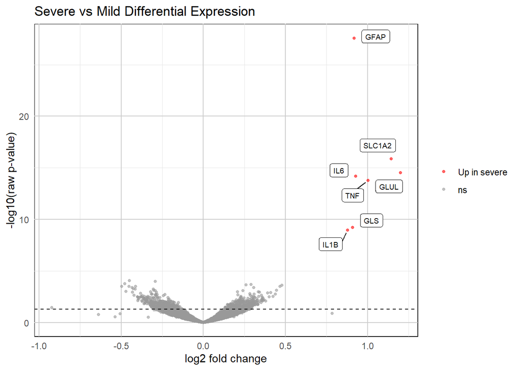

```r
plot_volcano <- function(results, title = "Severe vs Mild Differential Expression") {
  results <- results %>% filter(!is.na(logFC), !is.na(PValue), !is.na(FDR))

  results <- results %>%
    mutate(
      neg_log10_p = -log10(PValue),
      color = case_when(
        FDR <= 0.05 & logFC > 0 ~ "Up in severe",
        FDR <= 0.05 & logFC < 0 ~ "Down in severe",
        TRUE ~ "ns"
      ),
      color = factor(color, levels = c("Up in severe", "Down in severe", "ns"))
    )

  ggplot(results, aes(x = logFC, y = neg_log10_p, color = color)) +
    geom_point(alpha = 0.6, size = 1) +
    geom_label_repel(
      data = results %>% filter(color == "Up in severe"),
      aes(label = gene),
      color = "black",
      fill = "white",
      label.size = 0.2,
      size = 2.5,
      box.padding = 0.4,
      point.padding = 0.3,
      max.overlaps = Inf
    ) +
    geom_hline(yintercept = -log10(0.05), linetype = "dashed") +
    scale_color_manual(values = c(
      "Up in severe" = "red",
      "Down in severe" = "blue",
      "ns" = "gray60"
    )) +
    labs(
      x = "log2 fold change",
      y = "-log10(raw p-value)",
      title = title,
      color = NULL
    ) +
    theme_minimal() +
    theme(
      panel.background = element_rect(fill = "white"),
      plot.background = element_rect(fill = "white"),
      panel.grid.major = element_line(color = "grey80"),
      panel.grid.minor = element_line(color = "grey90")
    )
}

volcano_plot <- plot_volcano(de_results)

volcano_plot
```

```r
ggsave("part3/volcano_plot.png", volcano_plot, width = 8, height = 6, dpi = 300)
```

### 3.3.9 Save Environment

```r
save.image(file = "part3/workspace_part3.rda")

rm(list=ls())
```

# 4 **PART 4 - Communication**

## 4.1 Cumulative Hyperammonemic Burden is the Strongest Driver of Neurocognitive Decline

Longitudinal mixed‑effects modeling shows that while age and baseline severity explain initial differences in NCS, **cumulative HAE events (cumHAE)** are the most consistent predictor of *within‑patient* decline. Children with repeated metabolic crises show steeper cognitive deterioration, independent of subtype, gender, or transplant status. Clinically, this reinforces the importance of preventing recurrent moderate HAE episodes, which appear to have cumulative neurodevelopmental consequences through repeated astrocytic swelling, oxidative stress, and synaptic disruption.

## 4.4 Data Quality Considerations

Overall data quality was good, with no major outliers or labeling inconsistencies. However:

- **Multimodal overlap is limited** reducing power for integrated analyses: only ~250 samples have complete clinical, metabolomic, radiomic, and RNA‑seq data.
- **Missingness is not random**: younger and more severe patients are underrepresented in radiomics and metabolomics.
- **RNA‑seq QC** showed consistent read depth and minimal batch effects, but the small sample size limits power for gene‑level associations.
- **Clinical visit frequency varies** with some patients contributing only one or two timepoints, reducing precision for individual trajectories.

These issues do not invalidate findings but should guide interpretation.

## 4.5 Recommended Next Step

A focused prospective multimodal follow‑up is the most impactful next step. Specifically, collecting paired ammonia, Glx/Cr spectroscopy, and metabolomics at standardized timepoints would allow us to formally test the metabolic‑to‑neurocognitive pathway suggested here and identify early biomarkers of decline.

## 4.6 Central Figure

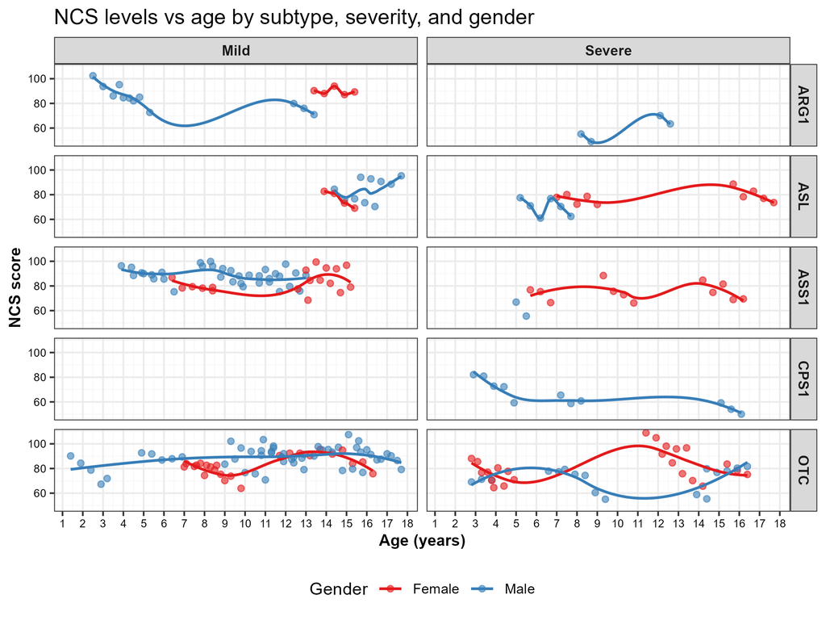

# 5 **PART 5 - Study Design**

## 5.1 Sampling Strategy

Given the budget for only 20 scRNA-seq samples, I would focus on a targeted sampling strategy rather than spreading samples evenly across all patients and visits. In Parts 1–2, cumulative HAE burden showed the strongest association with NCS, while metabolomics captured clearer molecular structure than bulk RNA-seq, which showed weaker but still suggestive signals (e.g., nitrogen metabolism and mitochondrial pathways). Based on that, I think the most informative scRNA-seq samples are those that capture differences in disease burden and trajectory, rather than just time. I would split the 20 samples into 12 longitudinal samples from 6 patients (2 visits each) and 8 cross-sectional samples from 8 additional patients (1 visit each). For the longitudinal group, I would select:

- 3 higher-risk “progressor” patients (high cumulative HAE, worsening NCS), and
- 3 more stable patients (lower burden, relatively stable NCS)

For each of these patients, I would choose two visits that maximize contrast—ideally an earlier visit and a later visit with higher cumulative HAE or a noticeable drop in NCS. The goal here is to capture within-patient changes that align with the patterns we saw in Part 2, rather than just picking arbitrary timepoints. For the remaining 8 samples, I would include single visits from patients at the extremes:

- some with high burden / worse clinical or metabolomic profiles, and
- some with milder or more stable disease

Whenever possible, I would prioritize visits that already have matching bulk RNA-seq and metabolomics data, since that makes the integration step much stronger. Overall, this approach tries to balance power and feasibility. The paired samples help control for between-patient variability, while the additional extreme samples increase the chances of seeing clear biological differences. It also uses what we already learned from the data instead of treating all visits as equally informative.

## 5.2 Analysis Pipeline and Integration with Bulk RNA-seq

After standard preprocessing (QC, normalization, batch correction), I would cluster the cells and annotate the main PBMC populations (e.g., monocytes, CD4/CD8 T cells, NK cells, B cells). From there, I would:

- estimate cell-type proportions per sample, and
- generate pseudobulk profiles for each cell type

I would then test whether higher-burden or declining-NCS samples show:

- shifts in cell composition (e.g., more activated monocytes), or
- changes within cell types, especially in pathways we already saw in bulk (mitochondrial stress, nitrogen metabolism, etc.)

### 5.2.1 Deconvolution:

These derived features (cell proportions and signature scores) could then be tested using the same longitudinal models from Part 2, looking at associations with cumulative HAE, NCS, and metabolomic PC1.

The main goal is to understand whether the bulk RNA-seq signals we saw are driven by:

- changes in cell composition,
- changes within specific cell types or
- combination of both

and whether these PBMC-based signals track with the metabolic and clinical measures in a meaningful way.

### 5.2.2 Key Limitation

One important limitation is that PBMC scRNA-seq reflects peripheral immune responses, which may not fully capture what is happening in the brain. Since the main outcomes here involve neurocognitive function and markers like ammonia and Glx/Cr, the blood signal is still an indirect readout. This means any findings would need to be interpreted cautiously in terms of CNS relevance.